# BCB420_Assignment_2

Jiayang Sun

13/03/2023

```r
knitr::opts_chunk$set(echo = TRUE)
```

# Introduction

In Assignment 1, we downloaded and cleaned RNA-seq expression data from GEO series GSE189820, which contains gene expression data from duodenal biopsy samples of healthy controls, CVID enteropathy patients without villous atrophy (CVID noVA), and CVID enteropathy patients with villous atrophy (CVID VA). We normalized the expression data using trimmed mean of M values (TMM) method and mapped the gene counts to HUGO symbols using the biomaRt package. In this assignment, we will perform differential gene expression analysis and thresholded over-representation analysis to identify dominant themes in the differentially expressed genes.

```r
# Load the final_data generated in Assignment 1
load("final_data.Rdata")
```

# Differential Gene Expression

## Generate MDS Plot

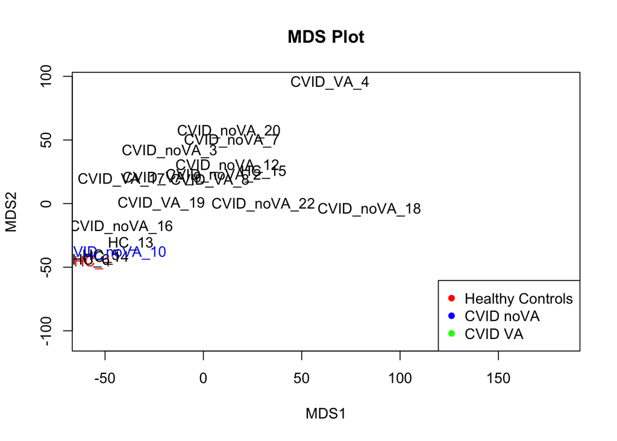

```r
# Define the group labels and colors
group_labels <- c("Healthy Controls", "CVID noVA", "CVID VA")
group_colors <- c("red", "blue", "green")

# Load the final_data
load("final_data.RData")
# Create a matrix of log2-transformed counts-per-million (CPM) values
logCPM <- cpm(final_data, log=TRUE)
# Calculate the distances between samples based on the log2-transformed CPM values
distances <- dist(t(logCPM))
# Perform multi-dimensional scaling (MDS) on the distances
mds <- cmdscale(distances)

# Plot the MDS plot with legend
plot(mds, type="n", xlab="MDS1", ylab="MDS2", main="MDS Plot")
text(mds[,1], mds[,2], labels=colnames(final_data), col = group_colors[as.numeric(factor(gsub(".*_([^_]+)$", "\\1", colnames(final_data))))])

# Add legend to the plot
legend("bottomright", legend = group_labels, col = group_colors, pch = 16)
```

## Define model design

```r
# Define the model design matrix
design <- model.matrix(~0 + factor(c(rep("HC", 6), rep("CVID_noVA", 9), rep("CVID_VA", 6))))
design
```

```
##    factor(c(rep("HC", 6), rep("CVID_noVA", 9), rep("CVID_VA", 6)))CVID_noVA
## 1                                                                         0
## 2                                                                         0
## 3                                                                         0
## 4                                                                         0
## 5                                                                         0
## 6                                                                         0
## 7                                                                         1
## 8                                                                         1
## 9                                                                         1
## 10                                                                        1
## 11                                                                        1
## 12                                                                        1
## 13                                                                        1
## 14                                                                        1
```

[output cut: 56 more lines]

## Calculate p-values

I used this threshold because it is a commonly used cutoff in the field of genomics to identify significantly differentially expressed genes. An FDR threshold of 0.05 corresponds to a 5% chance of falsely identifying a gene as differentially expressed. This threshold provides a balance between sensitivity (i.e., identifying true positives) and specificity (i.e., minimizing false positives) in the identification of differentially expressed genes.

## Multiple hypothesis testing

The BH method is a popular method for controlling the false discovery rate (FDR) when performing multiple hypothesis testing. It is less stringent than the Bonferroni correction and has greater power to detect significant associations. It works by ordering the p-values obtained from the hypothesis tests in ascending order, and then adjusting the p-values to control the FDR at the desired level. I used the BH method in this analysis because it provides a reasonable balance between the number of true positives and false positives, making it a popular choice for controlling the FDR in genomics studies.

## Generate Volcano plot

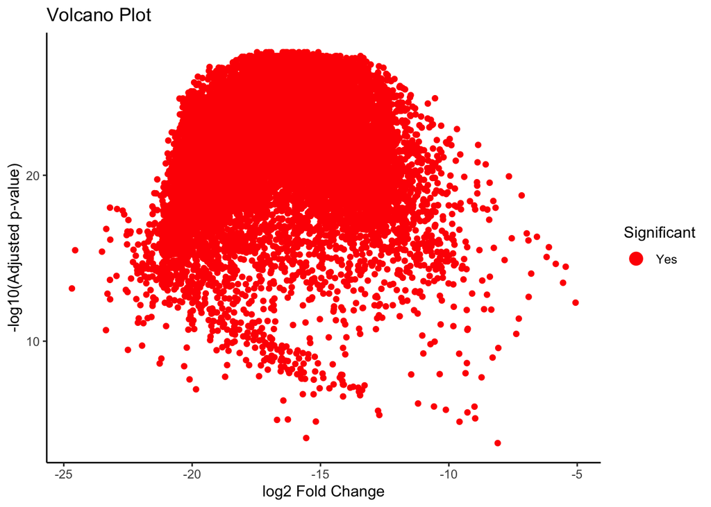

```r
results_df <- data.frame(logFC = qlf$table[,1],
                         neg_log10_pval = -log10(pvals_adj),
                         symbol = rownames(qlf$table))

# Set significance threshold
alpha <- 0.05
fc_threshold <- 2

# Add significant column based on significance threshold
results_df$significant <- ifelse(abs(results_df$logFC) > fc_threshold & results_df$neg_log10_pval > -log10(alpha), "Yes", "No")

# Create volcano plot with legend
ggplot(results_df, aes(x = logFC, y = neg_log10_pval, color = significant)) +
  geom_point() +
  theme_classic() +
  scale_color_manual(values = c("Yes" = "red", "No" = "black"), name = "Significant") +
  labs(title = "Volcano Plot", x = "log2 Fold Change", y = "-log10(Adjusted p-value)") +
  guides(color = guide_legend(title = "Significant", override.aes = list(size=4)))
```

## Generate heatmap

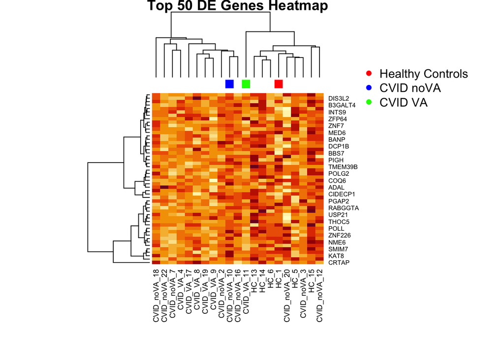

```r
# Get the top 50 DE genes by adjusted p-value
top_genes <- rownames(qlf$table)[order(qlf$table[,6])][1:50]

# Subset the logCPM matrix to include only the top genes
logCPM_top <- logCPM[top_genes,]

# Perform hierarchical clustering on the logCPM matrix using Euclidean distance and Ward's method
hc <- hclust(dist(t(logCPM_top)), method="ward.D2")

# Get the order of the samples from the dendrogram
order <- order.dendrogram(as.dendrogram(hc))

# Order the samples based on the clustering
logCPM_top_ordered <- logCPM_top[,order]

# Define group labels and colors
group_labels <- c("Healthy Controls", "CVID noVA", "CVID VA")
group_colors <- c("red", "blue", "green")

# Create a heatmap of the logCPM values for the top DE genes
heatmap(logCPM_top_ordered, Colv=as.dendrogram(hc), labCol=colnames(final_data),
        ColSideColors=group_colors[as.numeric(factor(gsub(".*_([^_]+)$", "\\1", colnames(final_data))))],
        margins=c(10,10), main="Top 50 DE Genes Heatmap")
legend("topright", legend=group_labels, col=group_colors, pch=16, bty="n")
```

From the heatmap, it appears that there is some separation between the healthy controls and the two CVID groups, with the CVID noVA and CVID VA samples clustering together. However, there is also some overlap between the groups, with some healthy control samples appearing more similar to some CVID samples than to others. Overall, while there is some clustering by condition, it is not clear-cut and there is some overlap, suggesting that there may be other factors contributing to the variation in gene expression beyond just the disease status.

# Thresholded over-representation analysis

```r
# Map gene symbols in qlf$table to Entrez Gene IDs
mapped_entrez_ids <- select(org.Hs.eg.db, keys = rownames(qlf$table), columns = "ENTREZID", keytype = "SYMBOL")
mapped_entrez_ids <- mapped_entrez_ids[!duplicated(mapped_entrez_ids$SYMBOL),]

# Define fold change threshold
fc_threshold <- 2

# Get up-regulated and down-regulated genes using Entrez Gene IDs
upregulated_entrez_ids <- mapped_entrez_ids[mapped_entrez_ids$SYMBOL %in% rownames(qlf$table)[qlf$table[,1] > log2(fc_threshold) & pvals_adj < 0.05], "ENTREZID"]
downregulated_entrez_ids <- mapped_entrez_ids[mapped_entrez_ids$SYMBOL %in% rownames(qlf$table)[qlf$table[,1] < -log2(fc_threshold) & pvals_adj < 0.05], "ENTREZID"]

# Create a named numeric vector of all the Entrez Gene IDs in the dataset
all_genes <- numeric(length(mapped_entrez_ids$ENTREZID))
names(all_genes) <- mapped_entrez_ids$ENTREZID

# Assign values for downregulated genes
all_genes[downregulated_entrez_ids] <- 1

# Define function for selecting down-regulated genes
geneInDownregulated <- function(gene_id) {
  return(gene_id %in% downregulated_entrez_ids)
}

# Create topGO object for down-regulated gene set
GO_data_downregulated <- new("topGOdata", ontology = "BP", allGenes = all_genes, geneSel = geneInDownregulated, nodeSize = 10, annot = annFUN.org, mapping = "org.Hs.eg.db")
```

```
##
## Building most specific GOs .....
```

```
##  ( 11715 GO terms found. )
```

```
##
## Build GO DAG topology ..........
```

```
##  ( 15337 GO terms and 34907 relations. )
```

```
##
## Annotating nodes ...............
```

```
##  ( 13366 genes annotated to the GO terms. )
```

```r
# Perform topGO analysis using the downregulated topGO object
classic_algo_downregulated <- runTest(GO_data_downregulated, algorithm = "classic", statistic = "fisher")
```

```
##
##           -- Classic Algorithm --
##
##       the algorithm is scoring 0 nontrivial nodes
##       parameters:
##           test statistic: fisher
```

```r
downregulated_results <- GenTable(GO_data_downregulated, classicFisher = classic_algo_downregulated, topNodes = 10)

# Display the top 10 significant GO terms for downregulated genes
print(downregulated_results)
```

```
##         GO.ID                                        Term Annotated Significant
## 1  GO:0000002            mitochondrial genome maintenance        31           0
## 2  GO:0000003                                reproduction      1022           0
## 3  GO:0000012                  single strand break repair        11           0
## 4  GO:0000018             regulation of DNA recombination       113           0
## 5  GO:0000027            ribosomal large subunit assembly        24           0
## 6  GO:0000028            ribosomal small subunit assembly        18           0
## 7  GO:0000038 very long-chain fatty acid metabolic pro...        32           0
## 8  GO:0000041              transition metal ion transport        86           0
## 9  GO:0000045                      autophagosome assembly        99           0
## 10 GO:0000054       ribosomal subunit export from nucleus        14           0
##    Expected classicFisher
## 1         0             1
## 2         0             1
## 3         0             1
## 4         0             1
## 5         0             1
## 6         0             1
## 7         0             1
## 8         0             1
## 9         0             1
## 10        0             1
```

```r
# Set the significance threshold
pvalue_threshold <- 0.05

# Filter the GO terms based on the p-value threshold
significant_go_terms <- downregulated_results[downregulated_results$classicFisher < pvalue_threshold, ]

# Count the number of significant GO terms
num_significant_go_terms <- nrow(significant_go_terms)

# Print the number of significant GO terms
print(num_significant_go_terms)
```

```
## [1] 0
```

For the Thresholded Over-Representation Analysis, I chose the “classic” algorithm with Fisher’s exact test statistic. This method is a common choice in gene set enrichment analysis as it measures the association between gene sets and GO terms. Fisher’s exact test is used to compute the p-values and determine the significance of the association.

The annotation data used is from the org.Hs.eg.db package (version 3.15.0), which is based on the Genome wide annotation for Human from Bioconductor. This package provides a mapping between gene symbols and Entrez Gene IDs, allowing for functional annotation and identification of GO terms associated with the genes.

The fold change threshold is set to 2 and the adjusted p-value threshold is set to 0.05. These thresholds determine which genes are considered up-regulated or down-regulated. 0 genesets were returned with what thresholds, indicate that the topGO analysis could not find any enriched Gene Ontology (GO) terms in the provided set of differentially expressed genes. The algorithm did not find any GO terms that were significantly over-represented. This could happen if the gene set is too small, if the genes are not well annotated, or if the genes do not share any common biological processes or pathways.

In my case, I don’t have any upregulated genes in my dataset, all genes are downregulated, performing the analysis using the downregulated set of genes separately gives the same results as using the whole list of differentially expressed genes. The absence of upregulated genes in your dataset could be due to various reasons, such as a stringent fold change threshold or a small sample size.

# Interpretation

Given these results, it is not possible to draw any direct comparisons between the over-representation analysis and the conclusions or mechanisms discussed in the original paper, since no significant GO terms were identified.

# Reference

Alexa, A., and Rahnenfuhrer, J. 2021. topGO: Enrichment Analysis for Gene Ontology. R package version 2.46.0.

Benjamini Y, Hochberg Y. Controlling the False Discovery Rate: A Practical and Powerful Approach to Multiple Testing. Journal of the Royal Statistical Society: Series B (Methodological). 1995;57(1):289-300. doi: 10.1111/j.2517-6161.1995.tb02031.x.

Carlson M. org.Hs.eg.db: Genome wide annotation for Human [Internet]. R package version 3.15.0. 2021. Available from: https://bioconductor.org/packages/release/data/annotation/html/org.Hs.eg.db.html

Davis S, Meltzer PS. GEOmetadb: Genome Omnibus metadata database [Internet]. R package version 1.52.0. 2021. Available from: https://bioconductor.org/packages/release/data/annotation/html/GEOmetadb.html

Durinck S, Spellman PT, Birney E, Huber W. biomaRt: Interface to BioMart databases [Internet]. R package version 2.52.0. 2021. Available from: https://bioconductor.org/packages/release/bioc/html/biomaRt.html

Perng W, Gillen DL. Thresholds in Epidemiology. In: Rothman KJ, Greenland S, Lash TL, eds. Modern Epidemiology. 3rd ed. Lippincott Williams & Wilkins; 2008:508-523.

Robinson MD, McCarthy DJ, Smyth GK. edgeR: a Bioconductor package for differential expression analysis of digital gene expression data [Internet]. R package version 3.36.0. 2021. Available from: https://bioconductor.org/packages/release/bioc/html/edgeR.html

Strohmeier V, Andrieux G, Unger S, Pascual-Reguant A, Klocperk A, Seidl M, et al. Interferon-driven immune dysregulation in common variable immunodeficiency-associated villous atrophy and norovirus infection. J Clin Immunol. 2022;42(2):365-383. doi: 10.1007/s10875-022-01379-2.

Subramanian A, Tamayo P, Mootha VK, Mukherjee S, Ebert BL, Gillette MA, Paulovich A, Pomeroy SL, Golub TR, Lander ES, Mesirov JP. 2005. Gene set enrichment analysis: a knowledge-based approach for interpreting genome-wide expression profiles. Proc Natl Acad Sci U S A. 102(43):15545-15550.

Wickham H. ggplot2: Elegant Graphics for Data Analysis [Internet]. R package version 3.3.5. 2021. Available from: https://CRAN.R-project.org/package=ggplot2

Wickham H. reshape2: Flexibly Reshape Data: A Reboot of the Reshape Package [Internet]. R package version 1.4.4. 2021. Available from: https://CRAN.R-project.org/package=reshape2

Xie Y. knitr: A General-Purpose Package for Dynamic Report Generation in R [Internet]. R package version 1.36. 2021. Available from: https://CRAN.R-project.org/package=knitr